# Tarea 1 Ejercicios

José Luis Jurado Ortiz

13/9/2021

# Ejercicio 1

Análisis exploratorio de un conjunto de datos y operaciones con dplyr.

## Ejercicio 1.1 y 1.2

```r
library(dplyr)
chlstrl <- read.csv(url("https://gist.githubusercontent.com/fsansegundo/ee991e53e1a571dd34034c42b5516eae/raw/2206455b5772e90c5a2a24a3f42a84408fd1d1c5/cholesterol.csv"))
head(chlstrl)
```

```
##   chol age gender height weight waist hip
## 1  203  46 female     62    121    29  38
## 2  165  29 female     64    218    46  48
## 3  228  58 female     61    256    49  57
## 4   78  67   male     67    119    33  38
## 5  249  64   male     68    183    44  41
## 6  248  34   male     71    190    36  42
```

## Ejercicio 1.3

Pregunta. Cuántas observaciones contiene?

```r
dim(chlstrl)
```

```
## [1] 403   7
```

Respuesta. Tiene 403 observaciones y 7 columnas

Pregunta. Cuáles son las variables y de qué tipos?

Respuesta.

```r
summary.default(chlstrl)
```

```
##        Length Class  Mode
## chol   403    -none- numeric
## age    403    -none- numeric
## gender 403    -none- character
## height 403    -none- numeric
## weight 403    -none- numeric
## waist  403    -none- numeric
## hip    403    -none- numeric
```

## Ejercicio 1.4

Pregunta. Asegúrate de comprobar si hay datos ausentes y localízalos en la tabla.

```r
(nan_values = which(is.na(chlstrl)))
```

```
##  [1]   28 1273 1296 1405 1441 1527 1774 2352 2409 2755 2812
```

```r
variable_categorica = chlstrl[3]
```

Respuesta. índices: 28 1273 1296 1405 1441 1527 1774 2352 2409 2755 2812

## Ejercicio 1.5

El análisis exploratorio (numérico y gráfico) debe cubrir todos los tipos de variable de la tabla. Es decir, que al menos debes estudiar una variable por cada tipo de variable presente en la tabla. El análisis debe contener, al menos:

– Para las variables cuantittativas (continuas o discretas). Resumen numérico básico. Gráficas (las adecuadas, a ser posible más de un tipo de gráfico).

– Variables categóricas (factores). Tablas de frecuencia (absolutas y relativas). Gráficas (diagrama de barras).

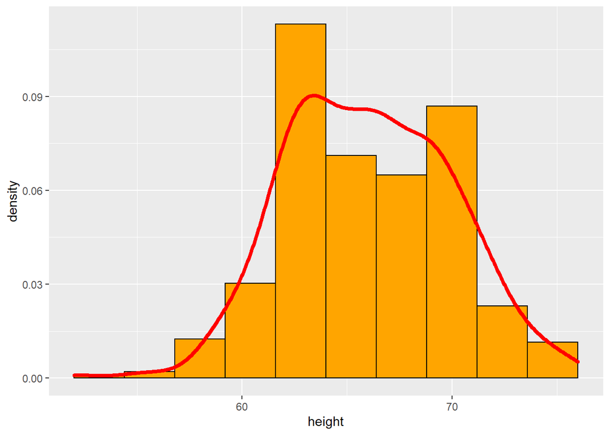

```r
library(ggplot2)
cortes = seq(min(chlstrl$height,na.rm = TRUE),max(chlstrl$height,na.rm = TRUE), length.out = 11)
ggplot(chlstrl, mapping = aes(height))+
  geom_histogram(aes(y = stat(density)),
                 breaks = cortes, fill = "orange", color = "black") +
  geom_density(color = "red",size = 1.5)
```

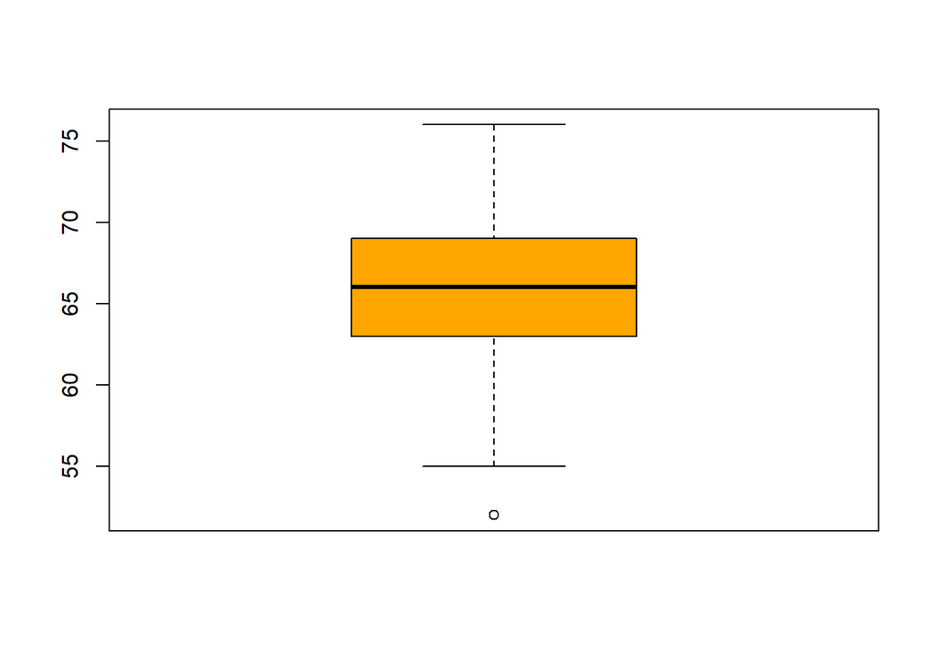

```r
boxplot(chlstrl$height, col="orange")
```

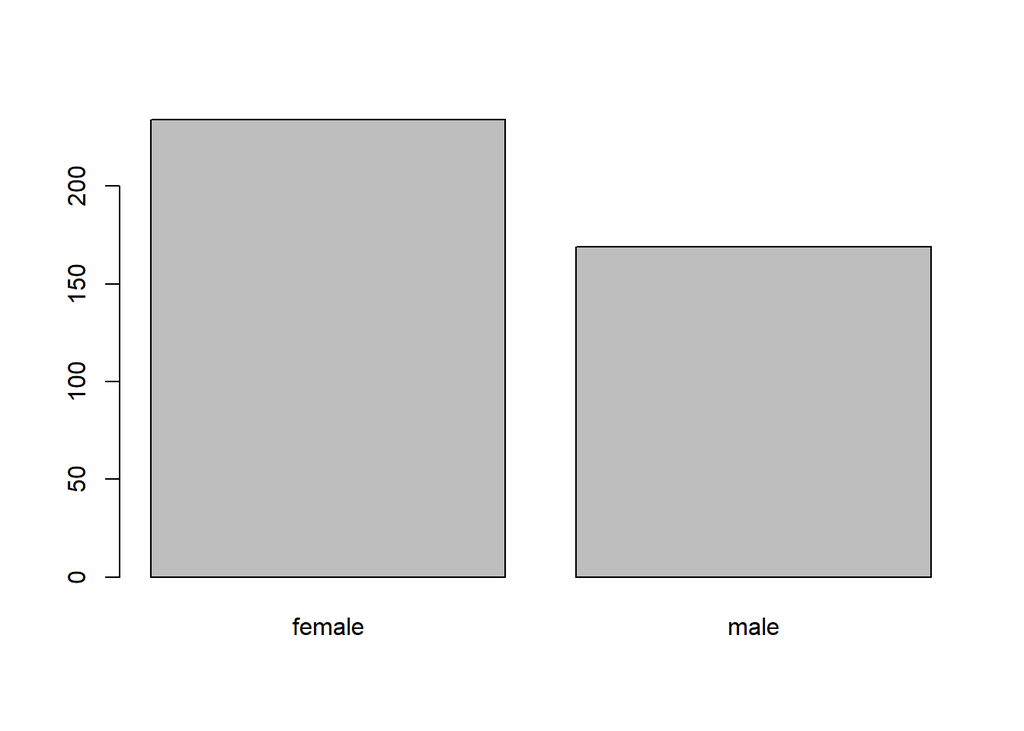

```r
barplot(table(chlstrl$gender))
```

## Ejercicio 1.6 y 1.7

```r
library(dplyr)

chlstrl_bmi <- chlstrl %>%
  mutate(height = height*0.0254, weight = weight*0.454) %>%
  mutate(bmi = weight/(height^2))
head(chlstrl_bmi)
```

```
##   chol age gender height  weight waist hip      bmi
## 1  203  46 female 1.5748  54.934    29  38 22.15085
## 2  165  29 female 1.6256  98.972    46  48 37.45286
## 3  228  58 female 1.5494 116.224    49  57 48.41375
## 4   78  67   male 1.7018  54.026    33  38 18.65459
## 5  249  64   male 1.7272  83.082    44  41 27.84977
## 6  248  34   male 1.8034  86.260    36  42 26.52316
```

## Ejercicio 1.8

```r
chlstrl_ageGroup_bmi <- chlstrl_bmi %>%
  mutate(ageGroup = ifelse(age %in% 10:40, "10_40", ifelse(age %in% 40:70,"40_70",ifelse(age %in% 70:100, "70_100","no"))))
head(chlstrl_ageGroup_bmi)
```

```
##   chol age gender height  weight waist hip      bmi ageGroup
## 1  203  46 female 1.5748  54.934    29  38 22.15085    40_70
## 2  165  29 female 1.6256  98.972    46  48 37.45286    10_40
## 3  228  58 female 1.5494 116.224    49  57 48.41375    40_70
## 4   78  67   male 1.7018  54.026    33  38 18.65459    40_70
## 5  249  64   male 1.7272  83.082    44  41 27.84977    40_70
## 6  248  34   male 1.8034  86.260    36  42 26.52316    10_40
```

## Ejercicio 1.9

```r
chlstrl_ageGroup_bmi %>%
  filter(gender == "female") %>%
  group_by(ageGroup) %>%
    summarise(bmi.media = mean(bmi,na.rm=T),
            chol.media = mean(chol,na.rm=T))
```

```
## # A tibble: 3 x 3
##   ageGroup bmi.media chol.media
##   <chr>        <dbl>      <dbl>
## 1 10_40         30.5       189.
## 2 40_70         30.3       221.
## 3 70_100        29.4       230.
```

# Ejercicio 2

## Ejercicio 2.1

Crea una función de R llamada cambiosSigno que dado un vector x de números enteros no nulos, como -12, -19, 9, -13, -14, -17, 8, -19, -14, calcule cuántos cambios de signo ha habido. Es decir, cuántas veces el signo de un elemento es distinto del signo del elemento previo. Por ejemplo, en el vector anterior hay 4 cambios de signo (en las posiciones 3, 4, 7 y 8).

```r
cambiosSigno <- function(vector){
  counter = 0
  for (indice in 2:length(vector)) {
    if (sign(vector[indice]) != sign(vector[indice-1])) {
      counter = counter + 1
    }
  }
  return(counter)
}

cambiosSigno(c(-12, -19, 9, -13, -14, -17, 8, -19, -14))
```

```
## [1] 4
```

## Ejercicio 2.2

```r
cambiosSignoPos <- function(vector){
  counter = c()
  for (indice in 2:length(vector)) {
    if (sign(vector[indice]) != sign(vector[indice-1])) {
      counter <- c(counter,indice)
    }
  }
  return(counter)
}

cambiosSignoPos(c(-12, -19, 9, -13, -14, -17, 8, -19, -14))
```

```
## [1] 3 4 7 8
```

```r
cambiosSignoPos(sample(-20:20,10))
```

```
## [1]  3  6  7  9 10
```

# Ejercicio 3

## Ejercicio 3.6.1

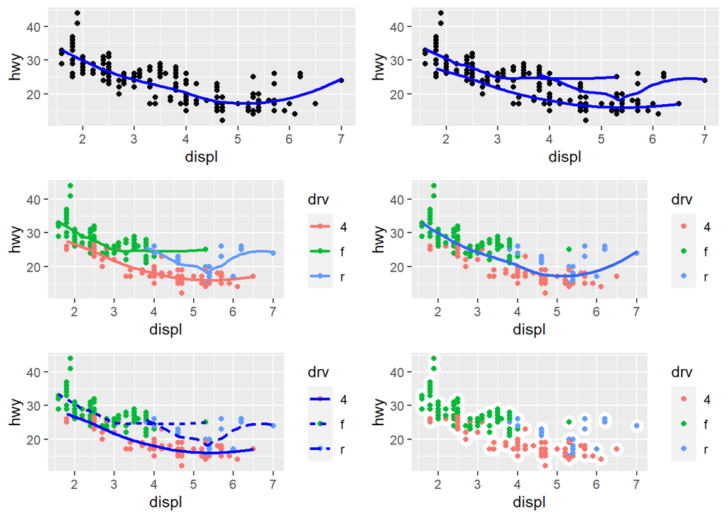

```r
library(ggplot2)
library(gridExtra)
plot1 <- ggplot(data = mpg, mapping = aes(x = displ, y = hwy)) +
  geom_point() +
  geom_smooth(se = F, color="blue")

plot2 <- ggplot(data = mpg, mapping = aes(x = displ, y = hwy)) +
  geom_point() +
  geom_smooth(se = F, color="blue", mapping = aes(group=drv))

plot3 <- ggplot(data = mpg, mapping = aes(x = displ, y = hwy, color=drv)) +
  geom_point() +
  geom_smooth(se = F)

plot4 <- ggplot(data = mpg, mapping = aes(x = displ, y = hwy)) +
  geom_point(mapping = aes(colour = drv)) +
  geom_smooth(se = F)

plot5 <- ggplot(data = mpg, mapping = aes(x = displ, y = hwy)) +
  geom_point(mapping = aes(color=drv)) +
  geom_smooth(se = F, color="blue", mapping = aes(linetype = drv))

plot6 <- ggplot(data = mpg, mapping = aes(x = displ, y = hwy)) +
  geom_point(size = 4, color = "white") +
  geom_point(aes(colour = drv))

gridExtra::grid.arrange(plot1,plot2,plot3,plot4,plot5,plot6,nrow=3)
```

## Ejercicio 5.2.4

Find all flights that

1. Had an arrival delay of two or more hours

```r
library("nycflights13")
library("tidyverse")
filter(flights, arr_delay >= 120)
```

```
## # A tibble: 10,200 x 19
##     year month   day dep_time sched_dep_time dep_delay arr_time sched_arr_time
##    <int> <int> <int>    <int>          <int>     <dbl>    <int>          <int>
##  1  2013     1     1      811            630       101     1047            830
##  2  2013     1     1      848           1835       853     1001           1950
##  3  2013     1     1      957            733       144     1056            853
##  4  2013     1     1     1114            900       134     1447           1222
##  5  2013     1     1     1505           1310       115     1638           1431
##  6  2013     1     1     1525           1340       105     1831           1626
##  7  2013     1     1     1549           1445        64     1912           1656
##  8  2013     1     1     1558           1359       119     1718           1515
##  9  2013     1     1     1732           1630        62     2028           1825
## 10  2013     1     1     1803           1620       103     2008           1750
## # ... with 10,190 more rows, and 11 more variables: arr_delay <dbl>,
## #   carrier <chr>, flight <int>, tailnum <chr>, origin <chr>, dest <chr>,
## #   air_time <dbl>, distance <dbl>, hour <dbl>, minute <dbl>, time_hour <dttm>
```

2. Flew to Houston (IAH or HOU)

```r
filter(flights, dest == "IAH" || dest == "HOU")
```

```
## # A tibble: 336,776 x 19
##     year month   day dep_time sched_dep_time dep_delay arr_time sched_arr_time
##    <int> <int> <int>    <int>          <int>     <dbl>    <int>          <int>
##  1  2013     1     1      517            515         2      830            819
##  2  2013     1     1      533            529         4      850            830
##  3  2013     1     1      542            540         2      923            850
##  4  2013     1     1      544            545        -1     1004           1022
##  5  2013     1     1      554            600        -6      812            837
##  6  2013     1     1      554            558        -4      740            728
##  7  2013     1     1      555            600        -5      913            854
##  8  2013     1     1      557            600        -3      709            723
##  9  2013     1     1      557            600        -3      838            846
## 10  2013     1     1      558            600        -2      753            745
## # ... with 336,766 more rows, and 11 more variables: arr_delay <dbl>,
## #   carrier <chr>, flight <int>, tailnum <chr>, origin <chr>, dest <chr>,
## #   air_time <dbl>, distance <dbl>, hour <dbl>, minute <dbl>, time_hour <dttm>
```

3. Were operated by United, American, or Delta

```r
filter(flights, carrier %in% c("AA", "DL", "UA"))
```

```
## # A tibble: 139,504 x 19
##     year month   day dep_time sched_dep_time dep_delay arr_time sched_arr_time
##    <int> <int> <int>    <int>          <int>     <dbl>    <int>          <int>
##  1  2013     1     1      517            515         2      830            819
##  2  2013     1     1      533            529         4      850            830
##  3  2013     1     1      542            540         2      923            850
##  4  2013     1     1      554            600        -6      812            837
##  5  2013     1     1      554            558        -4      740            728
##  6  2013     1     1      558            600        -2      753            745
##  7  2013     1     1      558            600        -2      924            917
##  8  2013     1     1      558            600        -2      923            937
##  9  2013     1     1      559            600        -1      941            910
## 10  2013     1     1      559            600        -1      854            902
## # ... with 139,494 more rows, and 11 more variables: arr_delay <dbl>,
## #   carrier <chr>, flight <int>, tailnum <chr>, origin <chr>, dest <chr>,
## #   air_time <dbl>, distance <dbl>, hour <dbl>, minute <dbl>, time_hour <dttm>
```

4. Departed in summer (July, August, and September)

```r
filter(flights, month %in% c(7:9))
```

```
## # A tibble: 86,326 x 19
##     year month   day dep_time sched_dep_time dep_delay arr_time sched_arr_time
##    <int> <int> <int>    <int>          <int>     <dbl>    <int>          <int>
##  1  2013     7     1        1           2029       212      236           2359
##  2  2013     7     1        2           2359         3      344            344
##  3  2013     7     1       29           2245       104      151              1
##  4  2013     7     1       43           2130       193      322             14
##  5  2013     7     1       44           2150       174      300            100
##  6  2013     7     1       46           2051       235      304           2358
##  7  2013     7     1       48           2001       287      308           2305
##  8  2013     7     1       58           2155       183      335             43
##  9  2013     7     1      100           2146       194      327             30
## 10  2013     7     1      100           2245       135      337            135
## # ... with 86,316 more rows, and 11 more variables: arr_delay <dbl>,
## #   carrier <chr>, flight <int>, tailnum <chr>, origin <chr>, dest <chr>,
## #   air_time <dbl>, distance <dbl>, hour <dbl>, minute <dbl>, time_hour <dttm>
```

5. Arrived more than two hours late, but didn’t leave late

```r
filter(flights, arr_delay > 120, dep_delay <= 0)
```

```
## # A tibble: 29 x 19
##     year month   day dep_time sched_dep_time dep_delay arr_time sched_arr_time
##    <int> <int> <int>    <int>          <int>     <dbl>    <int>          <int>
##  1  2013     1    27     1419           1420        -1     1754           1550
##  2  2013    10     7     1350           1350         0     1736           1526
##  3  2013    10     7     1357           1359        -2     1858           1654
##  4  2013    10    16      657            700        -3     1258           1056
##  5  2013    11     1      658            700        -2     1329           1015
##  6  2013     3    18     1844           1847        -3       39           2219
##  7  2013     4    17     1635           1640        -5     2049           1845
##  8  2013     4    18      558            600        -2     1149            850
##  9  2013     4    18      655            700        -5     1213            950
## 10  2013     5    22     1827           1830        -3     2217           2010
## # ... with 19 more rows, and 11 more variables: arr_delay <dbl>, carrier <chr>,
## #   flight <int>, tailnum <chr>, origin <chr>, dest <chr>, air_time <dbl>,
## #   distance <dbl>, hour <dbl>, minute <dbl>, time_hour <dttm>
```

6. Were delayed by at least an hour, but made up over 30 minutes in flight

```r
filter(flights, dep_delay >= 60, air_time > 30)
```

```
## # A tibble: 26,657 x 19
##     year month   day dep_time sched_dep_time dep_delay arr_time sched_arr_time
##    <int> <int> <int>    <int>          <int>     <dbl>    <int>          <int>
##  1  2013     1     1      811            630       101     1047            830
##  2  2013     1     1      826            715        71     1136           1045
##  3  2013     1     1      848           1835       853     1001           1950
##  4  2013     1     1      957            733       144     1056            853
##  5  2013     1     1     1114            900       134     1447           1222
##  6  2013     1     1     1120            944        96     1331           1213
##  7  2013     1     1     1301           1150        71     1518           1345
##  8  2013     1     1     1337           1220        77     1649           1531
##  9  2013     1     1     1400           1250        70     1645           1502
## 10  2013     1     1     1505           1310       115     1638           1431
## # ... with 26,647 more rows, and 11 more variables: arr_delay <dbl>,
## #   carrier <chr>, flight <int>, tailnum <chr>, origin <chr>, dest <chr>,
## #   air_time <dbl>, distance <dbl>, hour <dbl>, minute <dbl>, time_hour <dttm>
```

7. Departed between midnight and 6am (inclusive)

```r
filter(flights, dep_time %in% c(0:659))
```

```
## # A tibble: 31,429 x 19
##     year month   day dep_time sched_dep_time dep_delay arr_time sched_arr_time
##    <int> <int> <int>    <int>          <int>     <dbl>    <int>          <int>
##  1  2013     1     1      517            515         2      830            819
##  2  2013     1     1      533            529         4      850            830
##  3  2013     1     1      542            540         2      923            850
##  4  2013     1     1      544            545        -1     1004           1022
##  5  2013     1     1      554            600        -6      812            837
##  6  2013     1     1      554            558        -4      740            728
##  7  2013     1     1      555            600        -5      913            854
##  8  2013     1     1      557            600        -3      709            723
##  9  2013     1     1      557            600        -3      838            846
## 10  2013     1     1      558            600        -2      753            745
## # ... with 31,419 more rows, and 11 more variables: arr_delay <dbl>,
## #   carrier <chr>, flight <int>, tailnum <chr>, origin <chr>, dest <chr>,
## #   air_time <dbl>, distance <dbl>, hour <dbl>, minute <dbl>, time_hour <dttm>
```